# Data 607 Assignment Week 1

Leticia Salazar

8/27/2021

##### **Assignment Week 1:** Do Americans Approve or Disapprove the President’s Response to COVID-19?

##### Below you’ll find a dataset from fivethirtyeight.com titled “How Americans View Biden’s Response To The Coronavirus Crisis” [https://projects.fivethirtyeight.com/coronavirus-polls/]. Within the dataset there were a couple of csv files where I chose to look into two called covid_approval_polls.csv and covid_approval_polls_adjusted.csv. Both of these files look into American’s approval or disapproval of the way the US President is or has handled COVID-19, as well as a poll after adjustments were applied through a poll-averaging algorithm.

##### Explaination of columns in these datasets

- subject: this column marks whose handling of COVID-19 the approval poll is about
- party: party of respondents
  - **R**
  - **D**
  - **I**
  - **ALL**
- startdate: start date of poll
- enddate: end date of poll
- pollster: organization that conducted the poll
- sponsor: organization that sponsored the poll
- samplesize: size of polling sample
- population:
  - **A** for adults
  - **RV** for registered voters
  - **LV** for likely voters
- tracking: **True** if the poll is a tracking poll, meaning that the pollster is releasing data with overlapping samples
- text: text of the question the pollster asked
- url: link to the poll
- modeldate: date of model run
- grade: grade given to the pollster(website below)
  - https://projects.fivethirtyeight.com/pollster-ratings/
- weight: weight given to each poll in the model
- multiversions: __*__ denotes that multiple versions of a poll in the raw data file were combined

#### Loading the datasets and using the summary function to gain an overview of the datasets

```r
# Load the datasets

#theURL <- "https://raw.githubusercontent.com/fivethirtyeight/covid-19-polls/master/covid_approval_polls.csv"
#theURL2 <- "https://raw.githubusercontent.com/letisalba/Data607-Assignment-Week1/main/covid_approval_polls_adjusted.csv"

#approvaldf <- read.csv(file = theURL , header = TRUE , sep = ",",  na = ".")
#approval_adjusted <- read.csv(file = theURL2, header = TRUE, sep = ",",  na = ".")

#head(approvaldf)
#head(approval_adjusted)


# Load the datasets from my GitHub

theURL <- "https://raw.githubusercontent.com/letisalba/Data607-Assignment-Week1/main/covid_approval_polls.csv"
theURL2 <- "https://raw.githubusercontent.com/letisalba/Data607-Assignment-Week1/main/covid_approval_polls_adjusted.csv"

approval <- read.csv(file = theURL , header = TRUE , sep = ",",  na = ".")
approval_adjusted <- read.csv(file = theURL2, header = TRUE, sep = ",",  na = ".")

head(approval)
```

```
##   start_date   end_date        pollster   sponsor sample_size population party
## 1 2020-02-02 2020-02-04          YouGov Economist        1500          a   all
## 2 2020-02-02 2020-02-04          YouGov Economist         376          a     R
## 3 2020-02-02 2020-02-04          YouGov Economist         523          a     D
## 4 2020-02-02 2020-02-04          YouGov Economist         599          a     I
## 5 2020-02-07 2020-02-09 Morning Consult                  2200          a   all
## 6 2020-02-07 2020-02-09 Morning Consult                   684          a     R
##   subject tracking
## 1   Trump    FALSE
## 2   Trump    FALSE
## 3   Trump    FALSE
## 4   Trump    FALSE
## 5   Trump    FALSE
## 6   Trump    FALSE
##                                                                                                                                                        text
```

[output cut: 20 more lines]

```r
head(approval_adjusted)
```

```
##   subject modeldate party startdate   enddate              pollster grade
## 1   Biden 8/25/2021     D 1/24/2021 1/26/2021                YouGov    B+
## 2   Biden 8/25/2021     D 1/28/2021  2/1/2021 Quinnipiac University    A-
## 3   Biden 8/25/2021     D 1/29/2021  2/1/2021       Morning Consult     B
## 4   Biden 8/25/2021     D 1/31/2021  2/2/2021                YouGov    B+
## 5   Biden 8/25/2021     D  2/2/2021  2/2/2021     Data for Progress     B
## 6   Biden 8/25/2021     D  2/5/2021  2/7/2021                YouGov    B+
##   samplesize population    weight influence multiversions tracking approve
## 1     477.00          a 0.6285238         0                     NA   84.00
## 2     333.25          a 0.6317152         0                     NA   93.00
## 3     808.00         rv 0.8337467         0                     NA   89.00
## 4     484.00          a 0.5493243         0                     NA   88.00
## 5     564.00          a 0.8883977         0                     NA   89.22
## 6     336.00          a 0.3521874         0                     NA   88.00
##   disapprove approve_adjusted disapprove_adjusted            timestamp
## 1       3.00         86.91186            2.329323 10:20:07 25 Aug 2021
## 2       5.00         92.32067            5.472705 10:20:07 25 Aug 2021
## 3       7.00         90.42590            6.330154 10:20:07 25 Aug 2021
## 4       7.00         90.91186            6.329323 10:20:07 25 Aug 2021
## 5       7.14         89.62926            6.669734 10:20:07 25 Aug 2021
## 6       8.00         90.91186            7.329323 10:20:07 25 Aug 2021
##                                                                                                   url
## 1                                            https://docs.cdn.yougov.com/ld46rgtdlz/econTabReport.pdf
## 2                                          https://poll.qu.edu/national/release-detail?ReleaseID=3688
## 3 https://assets.morningconsult.com/wp-uploads/2021/02/03074817/2101110_crosstabs_POLITICO_RVs_v1.pdf
## 4                                            https://docs.cdn.yougov.com/460mactkmh/econTabReport.pdf
## 5      https://docs.google.com/spreadsheets/d/1dmzc8DpmtpppErDUVQWbqO9WofnPnccC4fQz2vEWDww/edit#gid=0
## 6          https://big.assets.huffingtonpost.com/athena/files/2021/02/11/6025c47bc5b6741597e0e0f2.pdf
```

#### Data Exploration

```r
# Print Summary for both datasets
summary(approval)
```

```
##   start_date          end_date           pollster           sponsor
##  Length:2809        Length:2809        Length:2809        Length:2809
##  Class :character   Class :character   Class :character   Class :character
##  Mode  :character   Mode  :character   Mode  :character   Mode  :character
##
##
##
##
##   sample_size      population           party             subject
##  Min.   :    55   Length:2809        Length:2809        Length:2809
##  1st Qu.:   389   Class :character   Class :character   Class :character
##  Median :   640   Mode  :character   Mode  :character   Mode  :character
##  Mean   :  2379
##  3rd Qu.:  1226
##  Max.   :325970
##  NA's   :22
##   tracking           text              approve        disapprove
##  Mode :logical   Length:2809        Min.   : 1.00   Min.   : 1.00
##  FALSE:2559      Class :character   1st Qu.:30.00   1st Qu.:28.00
##  TRUE :242       Mode  :character   Median :42.00   Median :53.00
##  NA's :8                            Mean   :46.42   Mean   :48.48
##                                     3rd Qu.:66.00   3rd Qu.:63.00
##                                     Max.   :98.00   Max.   :98.00
##                                     NA's   :3       NA's   :15
##      url
##  Length:2809
##  Class :character
##  Mode  :character
##
##
##
##
```

```r
summary(approval_adjusted)
```

```
##    subject           modeldate            party            startdate
##  Length:2711        Length:2711        Length:2711        Length:2711
##  Class :character   Class :character   Class :character   Class :character
##  Mode  :character   Mode  :character   Mode  :character   Mode  :character
##
##
##
##
##    enddate            pollster            grade             samplesize
##  Length:2711        Length:2711        Length:2711        Min.   :    36.8
##  Class :character   Class :character   Class :character   1st Qu.:   363.1
##  Mode  :character   Mode  :character   Mode  :character   Median :   600.0
##                                                           Mean   :  2384.5
##                                                           3rd Qu.:  1175.5
##                                                           Max.   :325970.0
##
##   population            weight          influence       multiversions
##  Length:2711        Min.   :0.02355   Min.   :0.00000   Length:2711
##  Class :character   1st Qu.:0.32528   1st Qu.:0.00000   Class :character
##  Mode  :character   Median :0.45790   Median :0.00000   Mode  :character
##                     Mean   :0.57263   Mean   :0.02789
##                     3rd Qu.:0.71632   3rd Qu.:0.00000
##                     Max.   :4.75767   Max.   :2.02269
##
##  tracking          approve        disapprove    approve_adjusted
##  Mode:logical   Min.   : 1.00   Min.   : 1.00   Min.   : 1.209
##  TRUE:242       1st Qu.:30.00   1st Qu.:28.00   1st Qu.:31.668
##  NA's:2469      Median :42.00   Median :52.00   Median :41.882
##                 Mean   :46.57   Mean   :48.34   Mean   :46.758
##                 3rd Qu.:67.00   3rd Qu.:63.00   3rd Qu.:64.533
##                 Max.   :98.00   Max.   :98.00   Max.   :96.426
##                 NA's   :3       NA's   :15      NA's   :3
##  disapprove_adjusted  timestamp             url
##  Min.   : 1.646      Length:2711        Length:2711
##  1st Qu.:28.977      Class :character   Class :character
##  Median :53.305      Mode  :character   Mode  :character
##  Mean   :48.816
##  3rd Qu.:62.700
##  Max.   :96.001
##  NA's   :15
```

```r
# Get column names for both data sets
colnames(approval, do.NULL = TRUE, prefix = "col")
```

```
##  [1] "start_date"  "end_date"    "pollster"    "sponsor"     "sample_size"
##  [6] "population"  "party"       "subject"     "tracking"    "text"
## [11] "approve"     "disapprove"  "url"
```

```r
colnames(approval_adjusted, do.NULL = TRUE, prefix = "col")
```

```
##  [1] "subject"             "modeldate"           "party"
##  [4] "startdate"           "enddate"             "pollster"
##  [7] "grade"               "samplesize"          "population"
## [10] "weight"              "influence"           "multiversions"
## [13] "tracking"            "approve"             "disapprove"
## [16] "approve_adjusted"    "disapprove_adjusted" "timestamp"
## [19] "url"
```

```r
# Print Mean and Median for selected columns of both data sets
means <- sapply(approval[, c("approve", "disapprove")], mean)
medians <- sapply(approval[, c("approve", "disapprove")], median)

means_medianDF <- data.frame(means, medians)
means_medianDF
```

```
##            means medians
## approve       NA      NA
## disapprove    NA      NA
```

```r
means2 <- sapply(approval_adjusted[, c("weight", "influence", "tracking", "approve_adjusted", "disapprove_adjusted")], mean)
medians2 <- sapply(approval_adjusted[, c("weight", "influence", "tracking", "approve_adjusted", "disapprove_adjusted")], median)


means_medianDF2 <- data.frame(means2, medians2)
means_medianDF2
```

```
##                         means2  medians2
## weight              0.57262824 0.4578976
## influence           0.02789216 0.0000000
## tracking                    NA        NA
## approve_adjusted            NA        NA
## disapprove_adjusted         NA        NA
```

```r
# Number of missing values in both data sets
colSums(is.na(approval))
```

```
##  start_date    end_date    pollster     sponsor sample_size  population
##           0           0           0           0          22           0
##       party     subject    tracking        text     approve  disapprove
##           0           0           8           0           3          15
##         url
##           0
```

```r
colSums(is.na(approval_adjusted))
```

```
##             subject           modeldate               party           startdate
##                   0                   0                   0                   0
##             enddate            pollster               grade          samplesize
##                   0                   0                   0                   0
##          population              weight           influence       multiversions
##                   0                   0                   0                   0
##            tracking             approve          disapprove    approve_adjusted
##                2469                   3                  15                   3
## disapprove_adjusted           timestamp                 url
##                  15                   0                   0
```

#### Data Wrangling

```r
# Create a new data frame with a subset of columns and rows for both data sets

approval_subset <- approval[, c("start_date", "end_date", "pollster", "sponsor", "sample_size", "population", "party", "approve", "disapprove")]
head(approval_subset)
```

```
##   start_date   end_date        pollster   sponsor sample_size population party
## 1 2020-02-02 2020-02-04          YouGov Economist        1500          a   all
## 2 2020-02-02 2020-02-04          YouGov Economist         376          a     R
## 3 2020-02-02 2020-02-04          YouGov Economist         523          a     D
## 4 2020-02-02 2020-02-04          YouGov Economist         599          a     I
## 5 2020-02-07 2020-02-09 Morning Consult                  2200          a   all
## 6 2020-02-07 2020-02-09 Morning Consult                   684          a     R
##   approve disapprove
## 1      42         29
## 2      75          6
## 3      21         51
## 4      39         25
## 5      57         22
## 6      88          4
```

```r
approval_adjusted_subset <- approval_adjusted[, c("subject", "party", "grade", "samplesize", "population", "weight", "influence", "approve_adjusted", "disapprove_adjusted")]
head(approval_adjusted_subset)
```

```
##   subject party grade samplesize population    weight influence
## 1   Biden     D    B+     477.00          a 0.6285238         0
## 2   Biden     D    A-     333.25          a 0.6317152         0
## 3   Biden     D     B     808.00         rv 0.8337467         0
## 4   Biden     D    B+     484.00          a 0.5493243         0
## 5   Biden     D     B     564.00          a 0.8883977         0
## 6   Biden     D    B+     336.00          a 0.3521874         0
##   approve_adjusted disapprove_adjusted
## 1         86.91186            2.329323
## 2         92.32067            5.472705
## 3         90.42590            6.330154
## 4         90.91186            6.329323
## 5         89.62926            6.669734
## 6         90.91186            7.329323
```

```r
# Create new column names for both data sets to create a new data frame
colnames(approval_subset) <- c("Start Date", "End Date", "Pollster", "Sponsor", "Sample Size", "Population", "Party", "Approve", "Disapprove")
colnames(approval_subset)
```

```
## [1] "Start Date"  "End Date"    "Pollster"    "Sponsor"     "Sample Size"
## [6] "Population"  "Party"       "Approve"     "Disapprove"
```

```r
colnames(approval_adjusted_subset) <- c("Subject", "Party_subset", "Grade", "Sample_Size", "Population_subset", "Weight", "Influence", "Approve_Adjusted", "Disapprove_Adjusted" )
colnames(approval_adjusted_subset)
```

```
## [1] "Subject"             "Party_subset"        "Grade"
## [4] "Sample_Size"         "Population_subset"   "Weight"
## [7] "Influence"           "Approve_Adjusted"    "Disapprove_Adjusted"
```

```r
# Print subset table to see new changes
head(approval_subset)
```

```
##   Start Date   End Date        Pollster   Sponsor Sample Size Population Party
## 1 2020-02-02 2020-02-04          YouGov Economist        1500          a   all
## 2 2020-02-02 2020-02-04          YouGov Economist         376          a     R
## 3 2020-02-02 2020-02-04          YouGov Economist         523          a     D
## 4 2020-02-02 2020-02-04          YouGov Economist         599          a     I
## 5 2020-02-07 2020-02-09 Morning Consult                  2200          a   all
## 6 2020-02-07 2020-02-09 Morning Consult                   684          a     R
##   Approve Disapprove
## 1      42         29
## 2      75          6
## 3      21         51
## 4      39         25
## 5      57         22
## 6      88          4
```

```r
head(approval_adjusted_subset)
```

```
##   Subject Party_subset Grade Sample_Size Population_subset    Weight Influence
## 1   Biden            D    B+      477.00                 a 0.6285238         0
## 2   Biden            D    A-      333.25                 a 0.6317152         0
## 3   Biden            D     B      808.00                rv 0.8337467         0
## 4   Biden            D    B+      484.00                 a 0.5493243         0
## 5   Biden            D     B      564.00                 a 0.8883977         0
## 6   Biden            D    B+      336.00                 a 0.3521874         0
##   Approve_Adjusted Disapprove_Adjusted
## 1         86.91186            2.329323
## 2         92.32067            5.472705
## 3         90.42590            6.330154
## 4         90.91186            6.329323
## 5         89.62926            6.669734
## 6         90.91186            7.329323
```

```r
# Number of missing values in both data sets subsets
colSums(is.na(approval_subset))
```

```
##  Start Date    End Date    Pollster     Sponsor Sample Size  Population
##           0           0           0           0          22           0
##       Party     Approve  Disapprove
##           0           3          15
```

```r
colSums(is.na(approval_adjusted_subset))
```

```
##             Subject        Party_subset               Grade         Sample_Size
##                   0                   0                   0                   0
##   Population_subset              Weight           Influence    Approve_Adjusted
##                   0                   0                   0                   3
## Disapprove_Adjusted
##                  15
```

#### Graphics

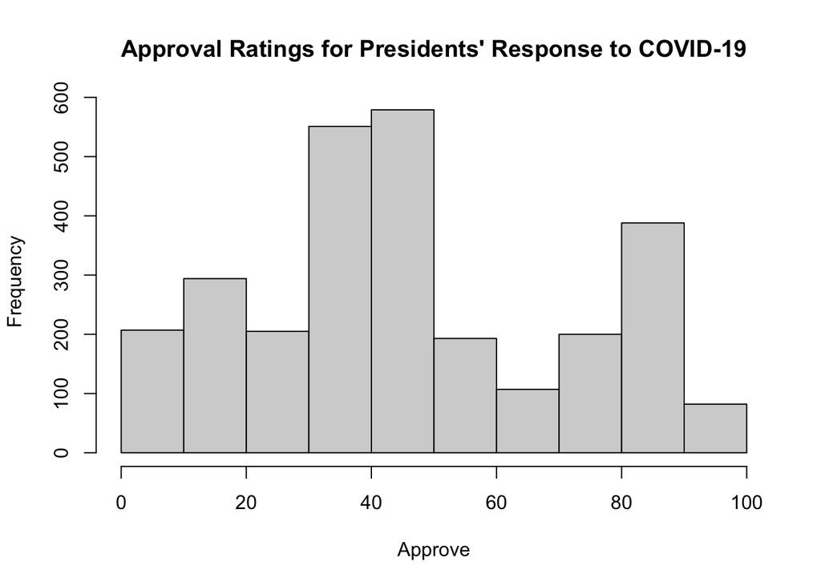

```r
# Histogram for approval ratings for COVID-19 presidential response
hist(approval_subset$Approve, main = "Approval Ratings for Presidents' Response to COVID-19", xlab = "Approve")
```

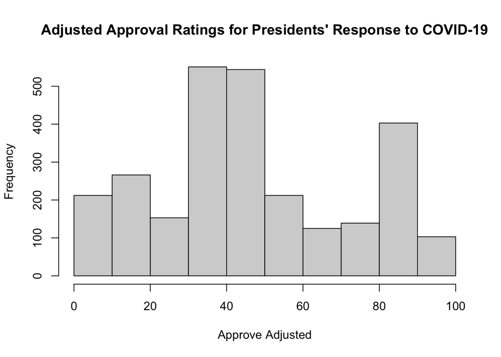

```r
# Histogram for adjusted approval ratings for COVID-19 presidential response
hist(approval_adjusted_subset$Approve_Adjusted, main = "Adjusted Approval Ratings for Presidents' Response to COVID-19", xlab = "Approve Adjusted")
```

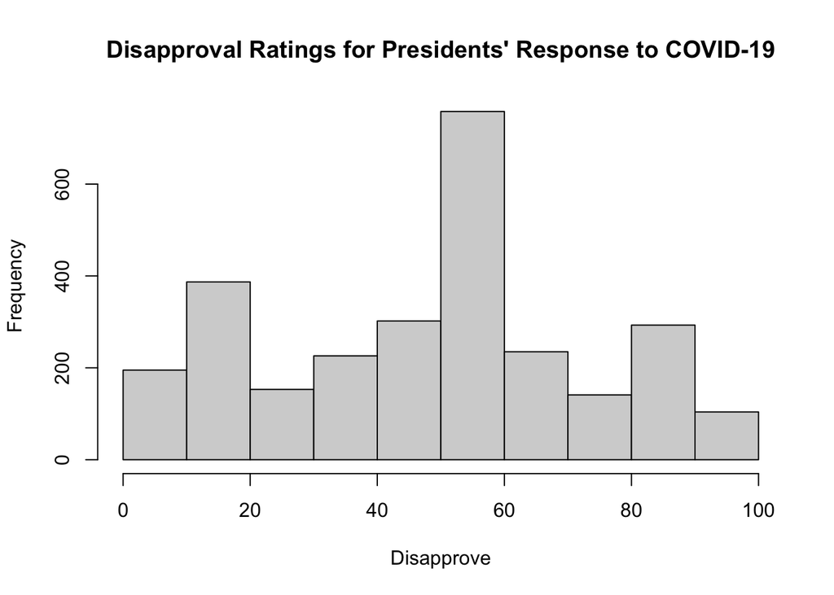

```r
# Histogram for disapproved ratings to COVID-19 presidental response
hist(approval_subset$Disapprove, main = "Disapproval Ratings for Presidents' Response to COVID-19", xlab = "Disapprove")
```

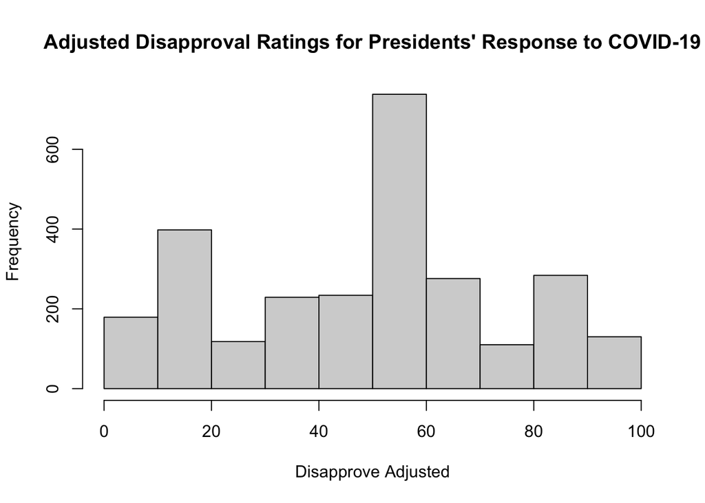

```r
# Histogram for adjusted disapproval ratings to COVID-19 presidential response
hist(approval_adjusted_subset$Disapprove_Adjusted, main = "Adjusted Disapproval Ratings for Presidents' Response to COVID-19", xlab = "Disapprove Adjusted")
```

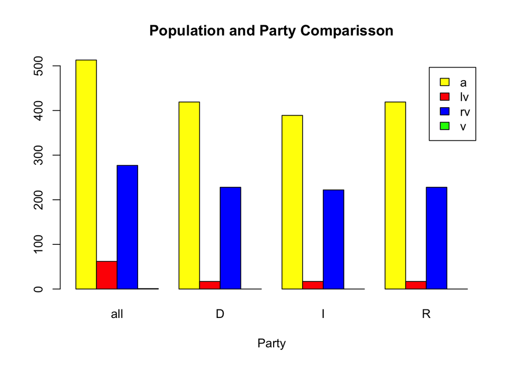

```r
# Grouped Bar graph comparing population and party from first data set
counts <- table(approval_subset$Population, approval_subset$Party)
barplot(counts, main="Population and Party Comparisson",
  xlab="Party", col=c("yellow", "red", "blue", "green"), legend = rownames(counts), beside=TRUE)
```

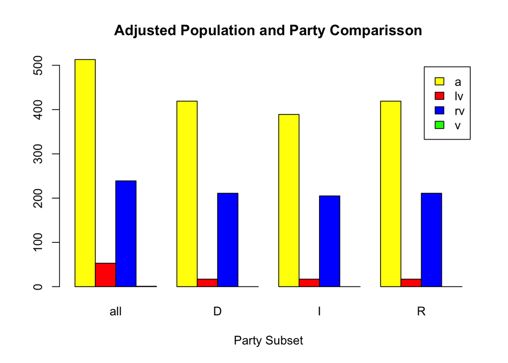

```r
# Grouped Bar graph comparing adjusted population and party
counts <- table(approval_adjusted_subset$Population_subset, approval_adjusted_subset$Party_subset)
barplot(counts, main="Adjusted Population and Party Comparisson",
  xlab="Party Subset", col=c("yellow", "red", "blue", "green"), legend = rownames(counts), beside=TRUE)
```

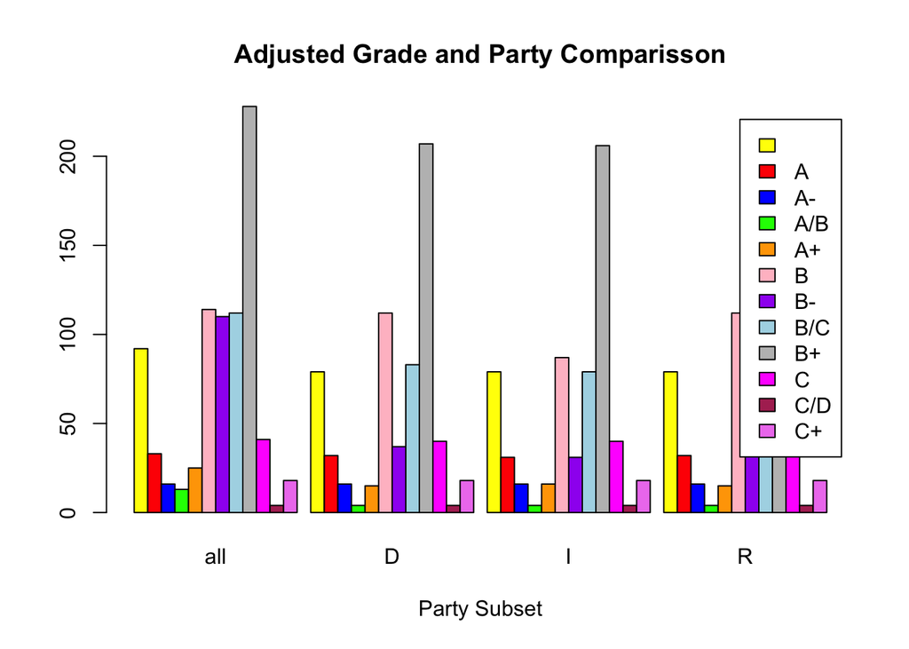

```r
# Grouped Bar graph comparing adjusted grade and party
counts <- table(approval_adjusted_subset$Grade, approval_adjusted_subset$Party_subset)
barplot(counts, main="Adjusted Grade and Party Comparisson",
  xlab="Party Subset", col=c("yellow", "red", "blue", "green", "orange", "pink", "purple", "lightblue", "gray", "magenta", "maroon", "violet"), legend = rownames(counts), beside=TRUE)
```

#### Moving forward I’d update a couple of things such as, joining both datasets to have a better understanding of the data collected. Getting rid of n/a and missing cell values, especially when trying to calculate the mean and median for “approve”, “disapprove”, “approve adjusted” and “disapprove adjusted”. Lastly I’d work with ggplot2 to create more interactive charts to analyze the data further.